# Part 1: Exploring Exponential Simulations and Their Center and Spread

Kimberly Bormann

2025-04-05

## Overview

This document explores the exponential distribution with simulations in R. We generate both individual exponential values and averages of multiple samples to compare their properties with theoretical expectations. The study uses histograms and overlaid density curves to visualize the differences between raw exponential data and the normally distributed sample means predicted by the Central Limit Theorem.

## Distributions

We will create two simulations to investigate and compare their shape, mean, and variance.

### First Distribution - Single Sample of Exponential Variables

The first distribution is 1000 random exponential variables with $\lambda$ = 0.2. Given our knowledge of exponential functions, we expect that when we visualize this distribution it will look very similar to the function used to generate the random variables which is $f(x) = 0.2e^{-0.2x}$, where x is randomly generated.

First we generate the variables.

```r
        #set lambda value
        lambda <- 0.2
        #simulation of 1000 random exponential values
        exp_raw <- rexp(1000, rate = lambda)
```

The first few entries of our single simulation of 1000 values: 4.2172863, 2.8830514, 6.6452743, 0.1578868, 0.2810549, 1.5825061

We can see the variables appear to be a collection of random exponential variables.

Now, let’s do the simple calculations for the theoretical means and variance for an exponential distribution with 1000 occurrences and $\lambda$ = 0.2.

```r
#calulate theoretical mean
theoretical_mean <- 1/lambda
#calulate theoretical variance
theoretical_sd <- 1/lambda
theoretical_var <- (1/lambda)^2
```

The Theoretical Mean: 5

The Theoretical Variance: 25

Next, we can view the distribution to see if it reflect our expectation that it is right skewed and decreasing with similar shape to the exponential function. To make this easier, I overlay the function $f(x) = 0.2e^{-0.2x}$ on the histogram.

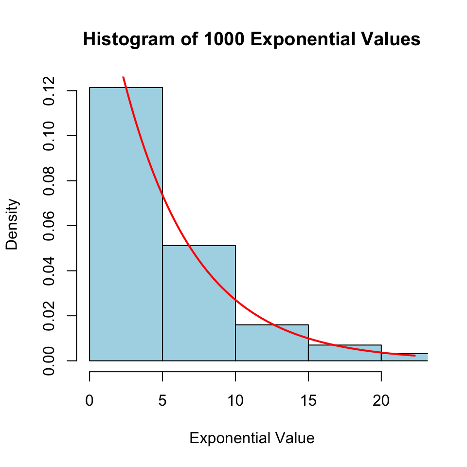

```r
        #histogram form 1000 exponential values
         hist(exp_raw, probability = TRUE,
             main = "Histogram of 1000 Exponential Values",
             xlab = "Exponential Value",
             col = "lightblue",
             xlim = c(0, quantile(exp_raw, 0.99))) #create a common scale for the function

        #overlay the theoretical exponential density curve
        curve(dexp(x, rate = lambda),
              from = 0,
              to = quantile(exp_raw, 0.99), #apply the common scale to the function
              add = TRUE,
              col = "red",
              lwd = 2)
```

This density function is right-skewed and decreaseing and is a close fit to the theoretical distribution in red.

The Law of Large Numbers(LLN) tells us that if the sample is large enough, the sample will approach the theoretical density curve. We can see that the random sample is a very close match to the theoretical density function therefore n=1000 is a good sample size.

To further support this, let’s compare the theoretical mean and variance to the sample mean and variance.

Sample Mean: 5.1498964  
Sample Variance: 25.2207028

Again, we can see that the sample and theoretical means and variance are very similar.

### Second Distribution - 1000 Sample Means of 40 Exponential Variables

This second distribution is 1000 samples of 40 exponential random variables with $\lambda$ = 0.2. After creating a matrix, we take the means of each sample(column) and investigate the averages of 1000 samples.

First, let’s generate the values.

```r
#generate 1000 simulation of 40 random exponential variables in a matrix where each column contains 40 random exponential variables.
n <- 40
n_sim <- 1000
sim_matrix <- matrix(rexp(n*n_sim, rate = lambda), nrow = n, ncol = n_sim)
#calculate the mean of each sample by finding the average of each column (this is our new data set)
sim_means <- apply(sim_matrix, 2, mean)
#calculate the variance of each sample (just for fun)
sim_vars <- apply(sim_matrix, 2, var)
```

First few averages from each sample:4.8019961, 4.4261485, 4.4172168, 4.967223, 5.4704708, 5.6579778  
First few variances from each sample: 20.8808216, 24.3205689, 19.2878375, 21.5869698, 19.2398573, 47.8443771

We will only use the sample averages moving forward.

Now let’s compare the sample mean and variance to the theoretical mean and variance.

The mean of the averages will be $1/\lambda$ as before. However the variance is the standard error squared or $\left(\frac{1}{\lambda \sqrt{n}}\right)^2$ because this distribution is the averages of 1000 samples.

```r
#theoretical mean calculation
lambda <- 0.2
theoretical_mean <- 1/lambda
#theoretical variance calulation
n <- 40
theoretical_sd <- 1/lambda
theoretical_se <- theoretical_sd/sqrt(n)
theoretical_mean_var <- theoretical_se^2
```

Theoretical Mean: 5  
Theoretical Variance of the Sample Mean: 0.625

Now let’s compare the sample means and variance to the theoretical ones.

```r
sample_mean <- round(mean(sim_means), 3)
sample_var <- round(var(sim_means), 3)
```

Sample Mean: 5.013  
Sample Variance: 0.604

As you can see the sample mean and variance is extremely close to the theoretical mean and variance. This suggests that the sample is normally distributed.

Lastly, let’s view the distribution. Unlike the first simulation which generated 1000 random exponential variables, this simulation generated 1000 means of random exponential variables.

For comparison, I overlay the normal distribution with theoretical mean and variance to the sample distribution.

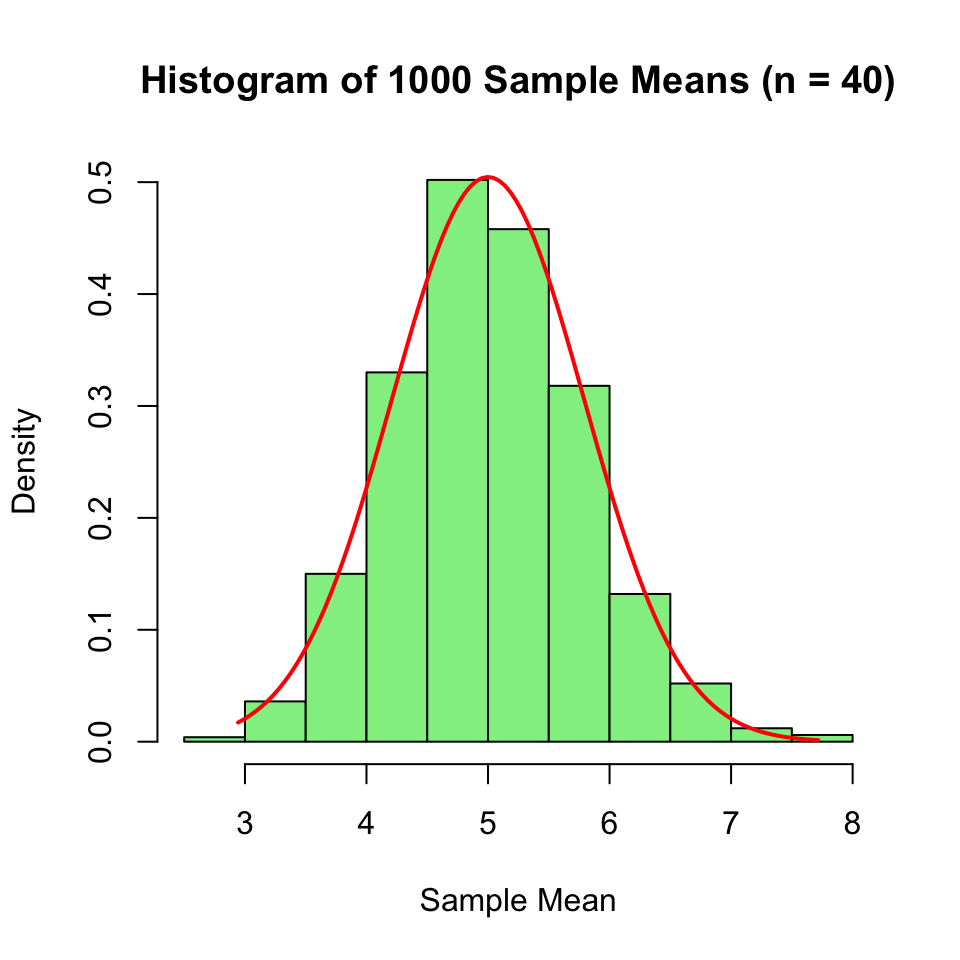

```r
#plot the histogram of sample means with density scaling
        hist(sim_means, probability = TRUE,
             main = "Histogram of 1000 Sample Means (n = 40)",
             xlab = "Sample Mean",
             col = "lightgreen")

#overlay the theoretical normal density curve
        curve(dnorm(x, mean = theoretical_mean, sd = sqrt(theoretical_mean_var)),
              from = min(sim_means), to = max(sim_means),
              add = TRUE, col = "red", lwd = 2)
```

We can see that the sample distribution fits the theortical model well and is normally distributed as expected.

## Summary

In conclusion, our simulations confirm that while individual exponential data is right-skewed, the distribution of sample means tends toward normality. The means and variances closely match the theoretical values, demonstrating the accuracy of our simulation.